# **Exploración de datos**

Paulina Rosales Becerra

2021-04-29

## General

Los puntos de la tarea vienen indicados con numeración.

### Librerías

Utilizadas para la graficación.

```r
library(ggplot2)
library(cowplot)
library(RColorBrewer)
```

### Datos

El set de datos está compuesto por carácterísticas de pacientes, enfocado a condiciones cardiovasculares.

#### Obtención

Leemos el archivo que vamos a visualizar

```r
setwd("/home/paulina/Documents/DataScience/Notebooks/")
dataset <- read.csv("source/cardiovascular_disease.csv")
# Cambiar tipo de dato de la columna gender para mejor manejo de datos
dataset$gender <- as.character(dataset$gender)
```

#### Características

Las categorías del set de datos son las siguientes:

```r
names(dataset)
```

```
##  [1] "id"          "age_days"    "age_year"    "gender"      "height"
##  [6] "weight"      "ap_hi"       "ap_lo"       "cholesterol" "gluc"
## [11] "smoke"       "alco"        "active"      "cardio"
```

## Filtrado de datos

División en dos grupos de acuerdo al género.

```r
# Filtrar los datos por género
dataset.female <- dataset[dataset$gender == "1",]
dataset.male <- dataset[dataset$gender == "2",]

# Además eliminamos aquellos datos que no tengan información (NA)
dataset.female <- na.omit(dataset.female)
dataset.male <- na.omit(dataset.male)
```

### Categorías de interés

Además nos concentraremos en 3 categorías distintas:

- Edad en años
- Peso
- Estaura

Elegí estos datos porque el análisis estadístico tiene más sentido utilizando variables numéricas. Además, para simplificar el manejo de datos eliminaré las categorías que no me interesan.

```r
dataset.female <- dataset.female[,c("age_year", "height", "weight")]
dataset.male <- dataset.male[,c("age_year", "height", "weight")]
```

### Redondeo de edad

Para que la edad en años sea máas fácil de interpretar, tomaré en cuenta los años cumplidos sin los meses. Esto lo hharé usando la función `floor` para redondear al entero menor.

```r
dataset.female$age_year <- floor(dataset.female$age_year)
dataset.male$age_year <- floor(dataset.male$age_year)
```

## Estadística descriptiva

### Medidas de Tendencia Central

De cada una de las categorías en en los dos grupos.

Para esto definí una función que me facilite el cáluclo de las Medidas de Tendencia Central:

```r
# FUNCIÓN GENERAL
CentalTendencies <- function(dataColumn){
  # Media
  mean <- mean(dataColumn)
  # Moda
  mode <- data.frame(table(dataColumn))
  mode <- mode[which.max(mode$Freq), 1]
  # Mediana
  median <- median(dataColumn)
  centralTendMeasures <- c(mean = mean, mode = mode, median = median)
  return(centralTendMeasures)
}
```

#### Grupo: Femenino

```r
# Por categoría
MMM.Age <- CentalTendencies(dataset.female$age_year)
MMM.Height <- CentalTendencies(dataset.female$height)
MMM.Weight <- CentalTendencies(dataset.female$weight)

MMM.FemData <- data.frame(Age = MMM.Age, Height = MMM.Height, Weigth = MMM.Weight)

MMM.FemData
```

```
##             Age   Height   Weigth
## mean   52.95434 161.3556 72.56561
## mode   19.00000  66.0000 79.00000
## median 54.00000 161.0000 70.00000
```

#### Grupo: Masculino

```r
# Por categoría
MMM.Age <- CentalTendencies(dataset.male$age_year)
MMM.Height <- CentalTendencies(dataset.male$height)
MMM.Weight <- CentalTendencies(dataset.male$weight)

MMM.MaleData <- data.frame(Age = MMM.Age, Height = MMM.Height, Weigth = MMM.Weight)

MMM.MaleData
```

```
##             Age   Height   Weigth
## mean   52.62918 169.9479 77.25731
## mode   16.00000  51.0000 59.00000
## median 53.00000 170.0000 75.00000
```

### Cuartiles

#### Grupo: Femenino

```r
# Por categoría
quant.Age <- quantile(dataset.female$age_year)
quant.Height <- quantile(dataset.female$height)
quant.Weight <- quantile(dataset.female$weight)

quant.FemData <- data.frame(Age = quant.Age, Height = quant.Height, Weigth = quant.Weight)

quant.FemData
```

```
##      Age Height Weigth
## 0%    29     55     21
## 25%   49    157     63
## 50%   54    161     70
## 75%   58    166     80
## 100%  64    250    200
```

#### Grupo: Masculino

```r
# Por categoría
quant.Age <- quantile(dataset.male$age_year)
quant.Height <- quantile(dataset.male$height)
quant.Weight <- quantile(dataset.male$weight)

quant.MaleData <- data.frame(Age = quant.Age, Height = quant.Height, Weigth = quant.Weight)

quant.MaleData
```

```
##      Age Height Weigth
## 0%    29     65     10
## 25%   47    165     68
## 50%   53    170     75
## 75%   58    175     85
## 100%  64    207    200
```

### Desviación Estándar

Referida como `SD` en el código.

#### Grupo: Femenino

```r
# Por categoría
SD.Age <- sd(dataset.female$age_year)
SD.Height <- sd(dataset.female$height)
SD.Weight <- sd(dataset.female$weight)

SD.FemData <- data.frame(Age = SD.Age, Height = SD.Height, Weigth = SD.Weight)

SD.FemData
```

```
##        Age   Height   Weigth
## 1 6.670351 7.052726 14.23884
```

#### Grupo: Masculino

```r
# Por categoría
SD.Age <- sd(dataset.male$age_year)
SD.Height <- sd(dataset.male$height)
SD.Weight <- sd(dataset.male$weight)

SD.MaleData <- data.frame(Age = SD.Age, Height = SD.Height, Weigth = SD.Weight)

SD.MaleData
```

```
##        Age   Height   Weigth
## 1 6.937803 7.228895 14.18764
```

## Resultados

### Distribución de datos

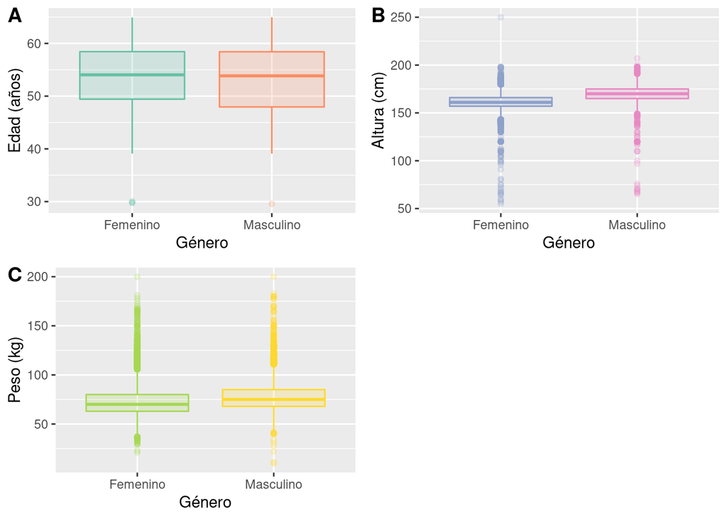

```r
colors <- brewer.pal(6, "Set2")
# Crear plots por categoría

# EDAD
box1 <- ggplot(dataset, aes(x = gender, y = age_year))  +
  geom_boxplot(color = colors[1:2], alpha = 0.2, fill = colors[1:2]) +
  scale_x_discrete(labels = c("Femenino", "Masculino")) +
  labs(x = "Género", y = "Edad (años)")

# ALTURA
box2 <- ggplot(dataset, aes(x = gender, y = height))  +
  geom_boxplot(color = colors[3:4], alpha = 0.2, fill = colors[3:4]) +
  scale_x_discrete(labels = c("Femenino", "Masculino")) +
  labs(x = "Género", y = "Altura (cm)")

# PESO
box3 <- ggplot(dataset, aes(x = gender, y = weight))  +
  geom_boxplot(color = colors[5:6], alpha = 0.2, fill = colors[5:6]) +
  scale_x_discrete(labels = c("Femenino", "Masculino")) +
  labs(x = "Género", y = "Peso (kg)")

# Unir las gráficas
plot_grid(box1, box2, box3, labels = "AUTO")
```

**Compara los resultados de tus 2 conjuntos, ¿existe alguna diferencia entre hombres y mujeres?**

Las estaturas y pesos del grupo masculino se concentran en la parte superior de la gráfica, lo que indica que los hombres tienden a ser más altos y pesados que las mujeres.

La diferencia es más clara en la estatura, sin embargo es importente destacar que ambas categorías tienen valores poco concentrados en la media (muy variantes).

La edad no representa un patrón particular de acuerdo al género.

### Correlación entre datos

#### Grupo: Femenino

```r
# Género: Femenino
corelation.FemData <- data.frame(Edad = dataset.female$age_year, Altura = dataset.female$height, Peso = dataset.female$weight)
corelationVal <- cor(corelation.FemData, method = "p")
corelationVal
```

```
##               Edad      Altura       Peso
## Edad    1.00000000 -0.07809504 0.08048217
## Altura -0.07809504  1.00000000 0.16145853
## Peso    0.08048217  0.16145853 1.00000000
```

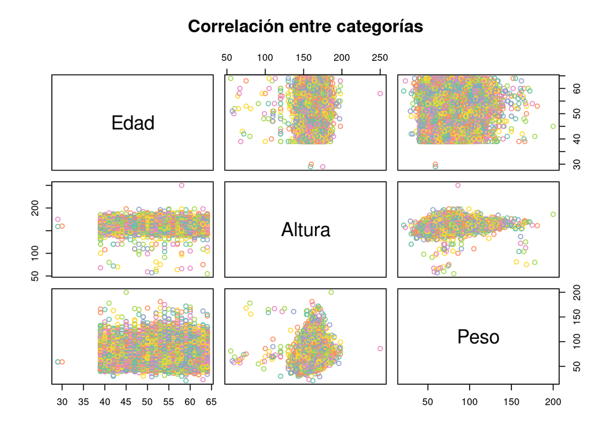

```r
pairs(corelation.FemData, col = colors, main = "Correlación entre categorías")
```

#### Grupo: Masculino

```r
corelation.MaleData <- data.frame(Edad = dataset.male$age_year, Altura = dataset.male$height, Peso = dataset.male$weight)
corelationVal <- cor(corelation.MaleData, method = "p")
corelationVal
```

```
##               Edad      Altura      Peso
## Edad    1.00000000 -0.08574891 0.0172207
## Altura -0.08574891  1.00000000 0.4094044
## Peso    0.01722070  0.40940445 1.0000000
```

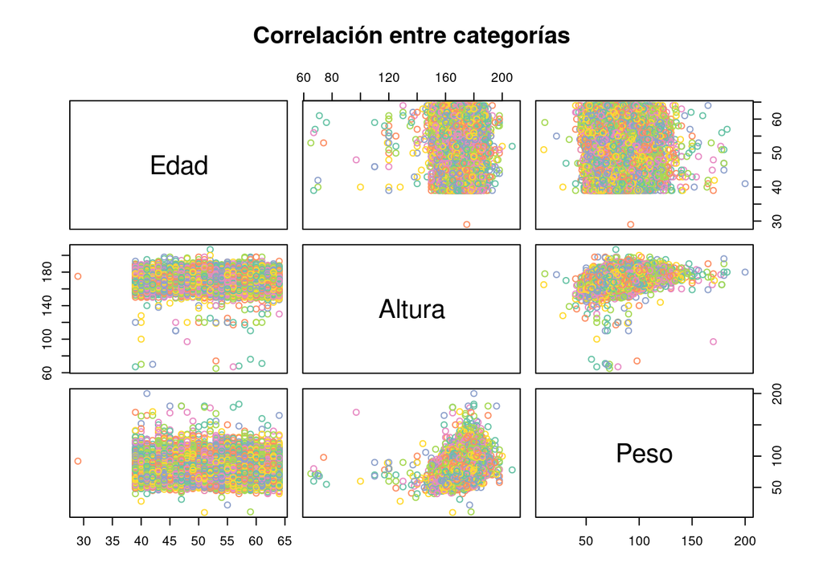

```r
pairs(corelation.MaleData, col = colors, main = "Correlación entre categorías")
```

**Interpreta tus resultados y comenta ¿por qué crees que hay o no correlación?.**

### Distribución Normal

#### Grupo: Femenino

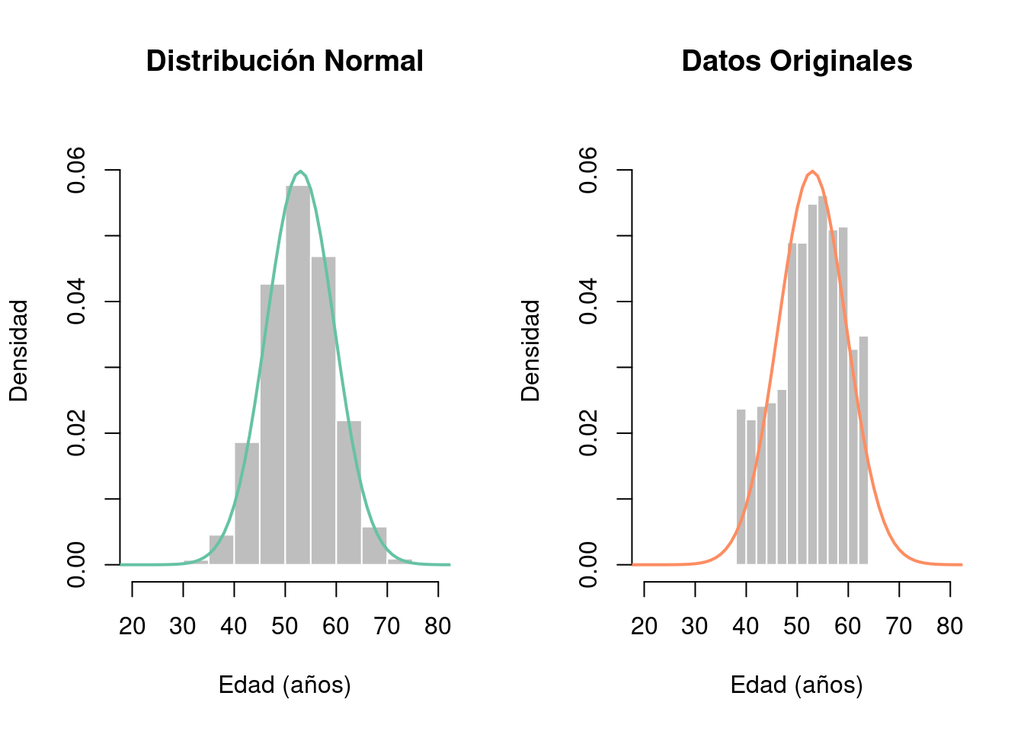

```r
set.seed(10)

# Valores principales
data <- dataset.female$age_year
mean <-  MMM.FemData$Age[1]
SD <- SD.FemData$Age

# Valores aleatorios
rNorm <-rnorm(n = length(data), mean = mean, sd = SD)

# Función de densidad
density <-seq(0, length(data), length = length(data))
dNorm <-dnorm(x = density , mean = mean, sd = SD)

# Graficación
par(mfrow=c(1, 2))
hist(rNorm,main = "Distribución Normal", freq = F, col = "gray", border = "white", xlim = c(20,80), ylim = c(0, 0.065), xlab = "Edad (años)", ylab = "Densidad")
lines(density, dNorm, lty = 1, lwd = 2, col = colors[1])
hist(data, main = "Datos Originales", freq = F, col = "gray", border = "white", xlim = c(20,80), ylim = c(0, 0.065), xlab = "Edad (años)", ylab = "Densidad")
lines(density, dNorm, col = colors[2], lty = 1, lwd = 2)
```

#### Grupo: Masculino

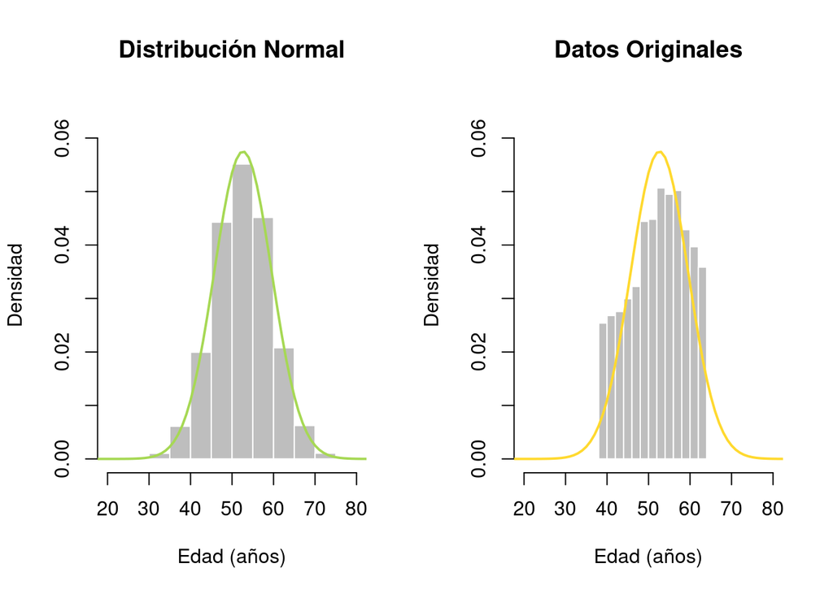

```r
# Valores principales
data <- dataset.male$age_year
mean <-  MMM.MaleData$Age[1]
SD <- SD.MaleData$Age

# Valores aleatorios
rNorm <-rnorm(n = length(data), mean = mean, sd = SD)

# Función de densidad
density <-seq(0, length(data), length = length(data))
dNorm <-dnorm(x = density , mean = mean, sd = SD)

# Graficación
par(mfrow=c(1, 2))
hist(rNorm,main = "Distribución Normal", freq = F, col = "gray", border = "white", xlim = c(20,80), ylim = c(0, 0.065), xlab = "Edad (años)", ylab = "Densidad")
lines(density, dNorm, lty = 1, lwd = 2, col = colors[5])
hist(data, main = "Datos Originales", freq = F, col = "gray", border = "white", xlim = c(20,80), ylim = c(0, 0.065), xlab = "Edad (años)", ylab = "Densidad")
lines(density, dNorm, col = colors[6], lty = 1, lwd = 2)
```

**¿Qué tanto se parecen las distribuciones normales (datos aleatorios) a los datos originales?**